# Manuscript Tables and Figures

Raahil Madhok

23 May, 2020

# 1 Overview

Sample selection protocol:

1. Stationary trips
2. Complete checklists (report all species)
3. Drop duplicates from group trips.
4. Drop trips with 1 bird
5. Duration between 5-240 mins
6. Keep trips from Homes (locality type = “Personal”)
7. For 2020 users, active in March and April for at least 10 days/month

## 1.1 Full Sample (All Districts)

| YEARMONTH | Num. Users | Num. Trips | Num. Species | Num. Cities |
| --- | --- | --- | --- | --- |
| 2019-03 | 843 | 4348 | 834 | 258 |
| 2019-04 | 655 | 3445 | 806 | 223 |
| 2020-03 | 95 | 3531 | 497 | 86 |
| 2020-04 | 95 | 6820 | 432 | 68 |

## 1.2 Top 20 Cities

City is not listed in eBird. Location identifiers include district, state, and coordinates. We select eBird cities that are in the top 20 by population density. Not all top 20 cities may be present in the eBird sample.

| COUNTY | state | pop_density |
| --- | --- | --- |
| East Delhi | Delhi | 27132.476 |
| Chennai | Tamil Nadu | 26552.754 |
| Kolkata | West Bengal | 24306.454 |
| Mumbai | Maharashtra | 20979.735 |
| South West Delhi | Delhi | 19563.408 |
| West Delhi | Delhi | 19563.408 |
| Hyderabad | Telangana | 18171.995 |
| Central Delhi | Delhi | 14557.016 |
| North East Delhi | Delhi | 14557.016 |
| South Delhi | Delhi | 11060.441 |
| North West Delhi | Delhi | 8254.038 |
| New Delhi | Delhi | 5446.456 |
| Bangalore | Karnataka | 4381.398 |
| Ghaziabad | Uttar Pradesh | 3970.861 |
| Haora | West Bengal | 3306.087 |
| Puducherry | Puducherry | 3232.276 |
| North 24 Parganas | West Bengal | 2444.988 |
| Faridabad | Haryana | 2442.285 |
| Varanasi | Uttar Pradesh | 2395.336 |
| Lakshadweep | Lakshadweep | 2149.100 |

## 1.3 Monthly Statistics

Discrepancy in number of users coming from users who birdwatched outside of top 20 cities in one of the month. For example, this could be a college student whose March trips were in a small town, and april trips were at his parents home in a big city.

NOTE: should we do the sample restriction AFTER selecting city list?

|  | V1 | V2 | V3 | V4 |
| --- | --- | --- | --- | --- |
| YEARMONTH | 2019-03 | 2019-04 | 2020-03 | 2020-04 |
| Num. Trips | 531 | 459 | 759 | 1336 |
| Num. Cities | 16 | 19 | 9 | 8 |
| Num. Users | 127 | 104 | 31 | 23 |
| Num. Species | 223 | 223 | 147 | 166 |

## 1.4 Trip Statistics

|  | V1 | V2 | V3 | V4 |
| --- | --- | --- | --- | --- |
| YEARMONTH | 2019-03 | 2019-04 | 2020-03 | 2020-04 |
| Trip Length | 27.46893 | 28.29847 | 22.59552 | 19.79491 |
| Species Richness | 10.344633 | 9.496732 | 10.044796 | 11.000749 |

## 1.5 Trip Statistics by City

| COUNTY | YEARMONTH | Trip Length | Species Richness |
| --- | --- | --- | --- |
| Bangalore | 2019-03 | 30.905882 | 11.094118 |
| Bangalore | 2019-04 | 31.178082 | 10.773973 |
| Bangalore | 2020-03 | 27.846154 | 11.622711 |
| Bangalore | 2020-04 | 24.816406 | 12.451172 |
| Central Delhi | 2019-04 | 7.000000 | 5.000000 |
| Central Delhi | 2020-03 | 10.000000 | 7.000000 |
| Chennai | 2019-03 | 17.559140 | 6.768817 |
| Chennai | 2019-04 | 16.475309 | 6.888889 |
| Chennai | 2020-03 | 14.758242 | 7.186813 |
| Chennai | 2020-04 | 16.144144 | 6.900901 |
| East Delhi | 2019-03 | 76.750000 | 10.375000 |
| East Delhi | 2019-04 | 5.000000 | 7.500000 |
| Faridabad | 2019-03 | 12.000000 | 18.000000 |
| Faridabad | 2019-04 | 30.857143 | 14.571429 |
| Ghaziabad | 2019-04 | 26.500000 | 7.000000 |
| Haora | 2019-03 | 180.000000 | 28.000000 |
| Haora | 2019-04 | 137.750000 | 29.500000 |
| Hyderabad | 2019-03 | 26.916667 | 12.333333 |
| Hyderabad | 2019-04 | 30.588235 | 11.294118 |
| Hyderabad | 2020-03 | 48.181818 | 14.090909 |
| Hyderabad | 2020-04 | 18.180328 | 10.836066 |
| Kolkata | 2019-03 | 24.023256 | 10.837209 |
| Kolkata | 2019-04 | 42.068965 | 9.655172 |
| Kolkata | 2020-03 | 24.796954 | 7.670051 |
| Kolkata | 2020-04 | 19.977273 | 9.344697 |
| Lakshadweep | 2019-04 | 73.500000 | 3.000000 |
| Mumbai | 2019-03 | 54.576923 | 13.384615 |
| Mumbai | 2019-04 | 77.066667 | 10.133333 |
| Mumbai | 2020-03 | 21.363636 | 8.000000 |
| Mumbai | 2020-04 | 15.689655 | 8.620690 |
| New Delhi | 2019-03 | 27.782609 | 8.260870 |
| New Delhi | 2019-04 | 43.923077 | 11.923077 |
| New Delhi | 2020-03 | 7.500000 | 8.000000 |
| New Delhi | 2020-04 | 10.000000 | 8.000000 |
| North 24 Parganas | 2019-03 | 22.500000 | 9.333333 |
| North 24 Parganas | 2019-04 | 19.714286 | 6.142857 |
| North East Delhi | 2019-03 | 60.000000 | 14.000000 |
| North West Delhi | 2019-03 | 95.000000 | 39.571429 |
| North West Delhi | 2019-04 | 65.000000 | 40.500000 |
| Puducherry | 2019-03 | 18.666667 | 18.777778 |
| Puducherry | 2019-04 | 12.000000 | 10.500000 |
| Puducherry | 2020-03 | 22.941177 | 15.164706 |
| Puducherry | 2020-04 | 16.545064 | 12.549356 |
| South Delhi | 2019-03 | 21.629630 | 15.185185 |
| South Delhi | 2019-04 | 37.500000 | 12.500000 |
| South Delhi | 2020-03 | 6.474359 | 8.346154 |
| South Delhi | 2020-04 | 9.960000 | 9.968000 |
| South West Delhi | 2019-03 | 20.400000 | 13.100000 |
| South West Delhi | 2019-04 | 21.136364 | 10.136364 |
| Varanasi | 2019-03 | 30.000000 | 10.000000 |
| Varanasi | 2019-04 | 15.000000 | 7.000000 |
| West Delhi | 2019-04 | 5.000000 | 8.000000 |

## 1.6 Marginal Species by city

Marginal species are species observed after lockdown which were not observed before lockdown. To implement: in each city, obtain list of species observed (across all users) in March and April 2020. Extract species in april list not in march list, and collect in a data frame. If fewer species in april, city will not be in final list.

| COMMON.NAME | COUNTY |
| --- | --- |
| owl sp. | Chennai |
| Glossy Ibis | Chennai |
| Red-wattled Lapwing | Chennai |
| sunbird sp. | Chennai |
| Asian Openbill | Chennai |
| Eurasian Moorhen | Kolkata |
| swift sp. | Kolkata |
| Gray-headed Swamphen | Kolkata |
| Red-breasted Parakeet | Kolkata |
| Fulvous-breasted Woodpecker | Kolkata |
| Painted Stork | Kolkata |
| falcon sp. | Kolkata |
| Asian Openbill | Kolkata |
| Rufous Woodpecker | Kolkata |
| Little Egret | Kolkata |
| Spotted Owlet | Kolkata |
| Zitting Cisticola | Kolkata |
| Brown-breasted Flycatcher | Kolkata |
| small swift sp. | Kolkata |
| Paddyfield Pipit | Kolkata |
| Jungle Babbler | Mumbai |
| Asian Pied Starling | Mumbai |
| Purple-rumped Sunbird | Mumbai |
| Pale-billed Flowerpecker | Mumbai |
| Red-vented Bulbul | Mumbai |
| Common Tailorbird | Mumbai |
| White-rumped Shama | Mumbai |
| Ashy Prinia | Mumbai |
| Gray-bellied Cuckoo | Hyderabad |
| swallow sp. | Hyderabad |

[output cut: 57 more lines]

# 2 Event Study - Regression Disconinuity

Each black point is the difference in species richness compared to the day of lockdown. Specifically, we compute the number of days from each trip until the day of lockdown (negative values are days until lockdown, positive values are days after lockdown). We regress species richness on dummies for time until lockdown with date, hour, and state fixed effects. We also control for duration of trip and number of trips per day for each user.

NOTE: add user fixed effects? Absorbs a lot of variation. Users are already very similar. Main benefit is controlling for unobserved, innate differences across users.

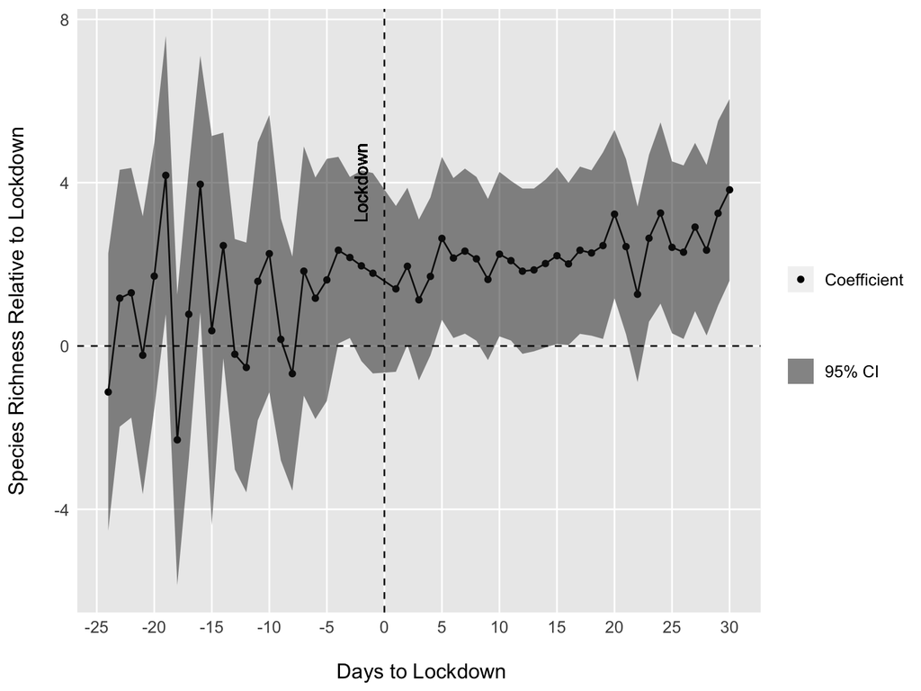

## 2.1 Species Distributions (Bangalore Only)

data: number of times each user sees each species in march and april. interpretation: proportion of user base seeing different frequencies of species.

[figure not shown]